# Titanic Dataset EDA and Modeling

## Introduction

Given a dataset of attributes for passengers on the Titanic, we will attempt to model and predict whether or not each passenger survived the sinking. After some data preprocessing, we perform an exploratory data analysis and model the data using a variety of algorithms. We combine the best trained models for each algorithm and combine their predictions on the test set. We produce two submission files ready for [Kaggle](https://www.kaggle.com/c/titanic), producing a score within the top 22% percent of participants.

First we load our libraries and our data. Make sure your current working directory is set to the root directory of this repo.

```r
library(tidyverse)
library(caTools)
library(pROC)
library(class)
library(randomForest)
library(gbm)
library(e1071)
library(MASS)
# Data import and preprocessing
# Load data (make sure your current working directory is set to this repo's root)
df_train = read_csv('data/train.csv')
df_test = read_csv('data/test.csv')
```

Let’s identify which variables contains NAs in the training set and the test set, and save these for later.

```r
# Variables in df_train with NAs: Age, Cabin, Embarked
var_has_NAs_train <- df_train %>% apply(2, is.na) %>% apply(2, any)
vars_with_NAs_train <- names(var_has_NAs_train[var_has_NAs_train])
print(vars_with_NAs_train)
```

```
## [1] "Age"      "Cabin"    "Embarked"
```

```r
# Variables in df_test with NAs: Age, Cabin, Fare
var_has_NAs_test <- df_test %>% apply(2, is.na) %>% apply(2, any)
vars_with_NAs_test <- names(var_has_NAs_test[var_has_NAs_test])
print(vars_with_NAs_test)
```

```
## [1] "Age"   "Fare"  "Cabin"
```

We’ll need to convert the variables we know to be categorical from numeric or character data types to factors.

```r
# Convert categorical data to factors
df_train$Survived <- df_train$Survived > 0
df_train$Sex <- factor(df_train$Sex)
df_train$Pclass <- factor(df_train$Pclass)
df_train$Embarked <- factor(df_train$Embarked)
```

Now we compute some new features that may or may not be useful. Our visualizations will tell us which is the case.

```r
# New features. We will visualize these to see if any of them are promising.
df_train$AgeIsNA <- is.na(df_train$Age)
df_train$Young <- df_train$Age < 18 & !is.na(df_train$Age)

df_train$CabinIsNA <- is.na(df_train$Cabin)

df_train$OneSibSp <- df_train$SibSp == 1
df_train$NonzeroSibSp <- df_train$SibSp > 0
df_train$OneOrTwoSibSp <- df_train$SibSp == 1 | df_train$SibSp == 2
df_train$ManySiblings <- df_train$SibSp > 2

df_train$OneOrTwoParch <- df_train$Parch == 1 | df_train$Parch == 2
df_train$OneTwoOrThreeParch <- df_train$Parch == 1 | df_train$Parch == 2 | df_train$Parch == 3
df_train$NonzeroParch <- df_train$Parch > 0
df_train$ManyChildren <- df_train$Parch > 3  # Can't have more than 2 parents, so the rest must be children

df_train$TicketIsNumeric <- df_train$Ticket %>% as.numeric() %>% is.na() %>% !.
median_ticket_number <- df_train$Ticket %>% as.numeric() %>% median(na.rm = TRUE)
df_train$TicketNumberAboveMedian <- df_train$Ticket > median_ticket_number
```

## Exploratory data analysis

We’re ready to begin our exploratory data analysis. We’ll explore any relationships that might seem interesting, and undoubtedly many will lead to dead ends.

First we see that `Pclass` and `Sex` seem highly correlated with survival, `Age` seems slightly correlated, and `Fare` seems uncorrelated.

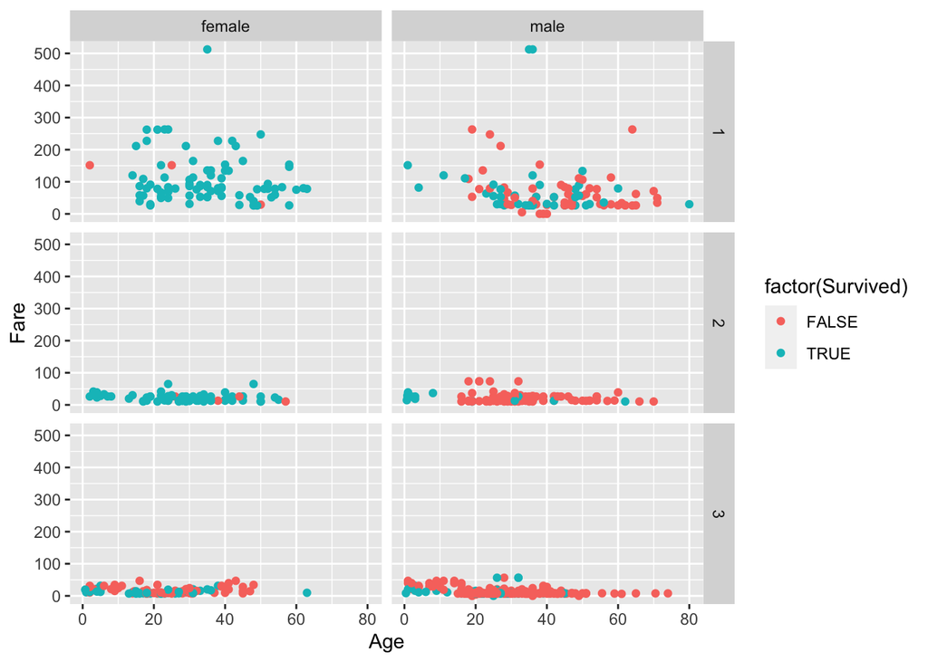

```r
ggplot(df_train, aes(Age, Fare)) + geom_point(aes(color = factor(Survived))) + facet_grid(Pclass ~ Sex)
```

`Fare` and `Pclass` seem highly correlated, as expected.

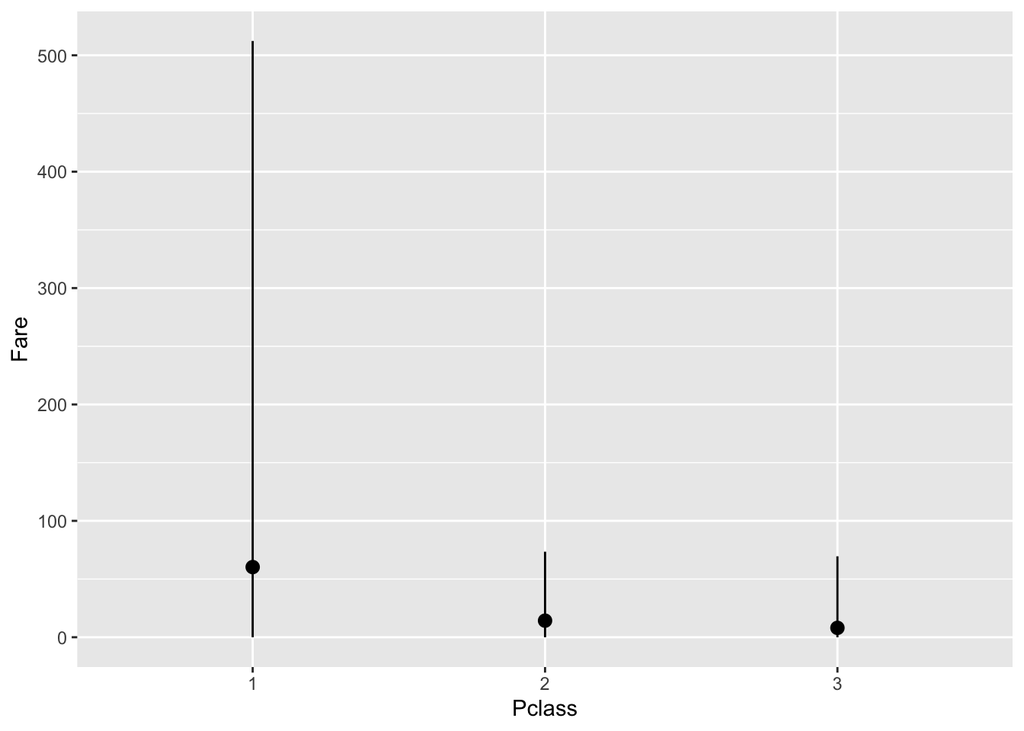

```r
ggplot(df_train) + stat_summary(aes(Pclass, Fare), fun.min = min, fun.max = max, fun = median)
```

Almost no first class passengers embarked at `Q`. Most passengers embarked at `S`. Intuitively, place of embarkment probably has nothing to do with survival, so we will ignore it for now. You may want to question this later.

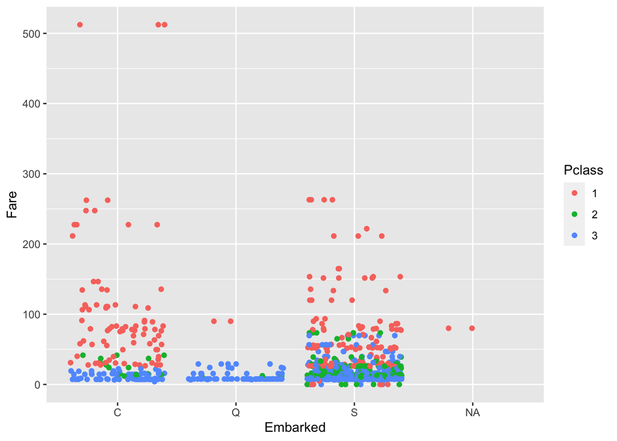

```r
ggplot(df_train, aes(Embarked, Fare, color = Pclass)) + geom_jitter()
```

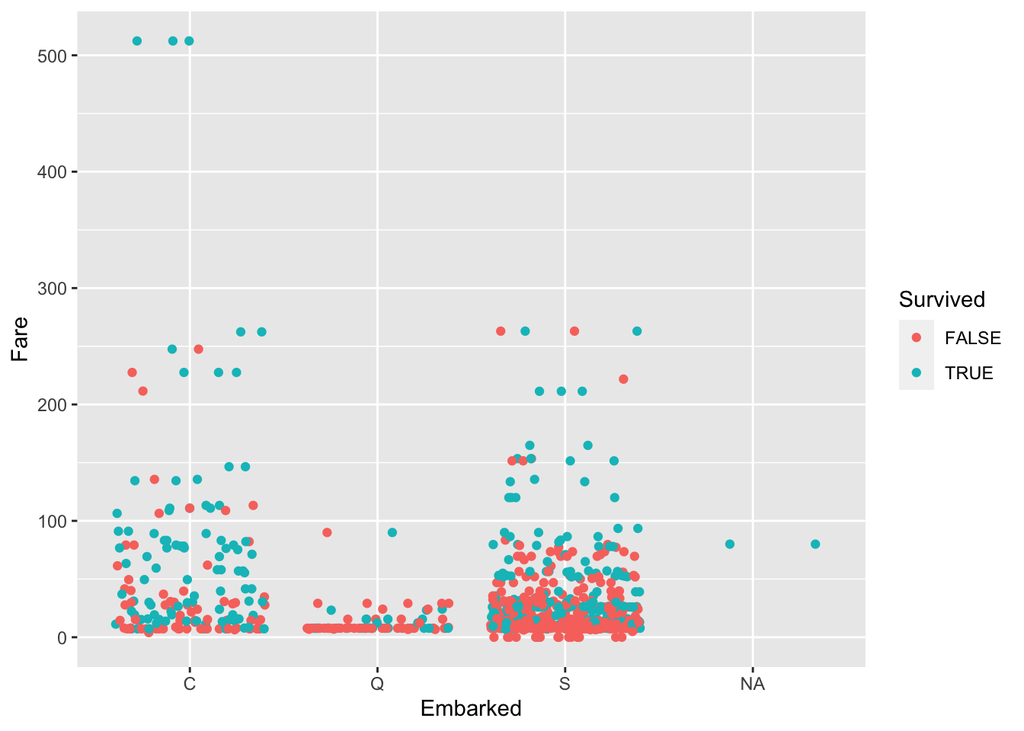

```r
ggplot(df_train, aes(Embarked, Fare, color = Survived)) + geom_jitter()
```

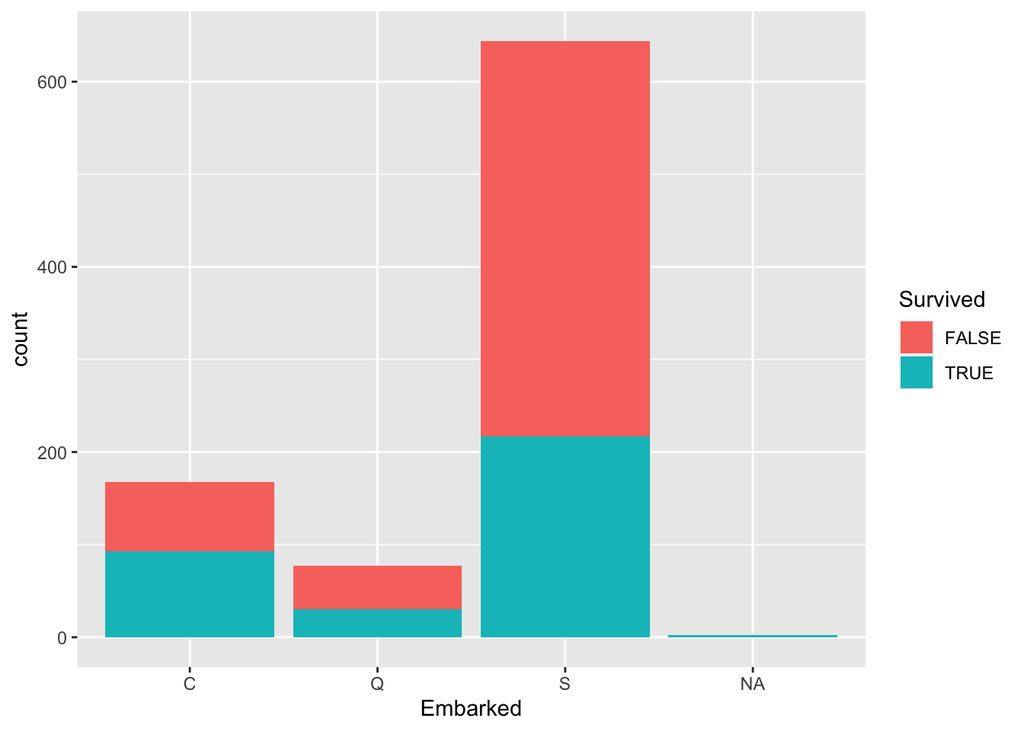

```r
ggplot(df_train, aes(Embarked, fill = Survived)) + geom_bar()
```

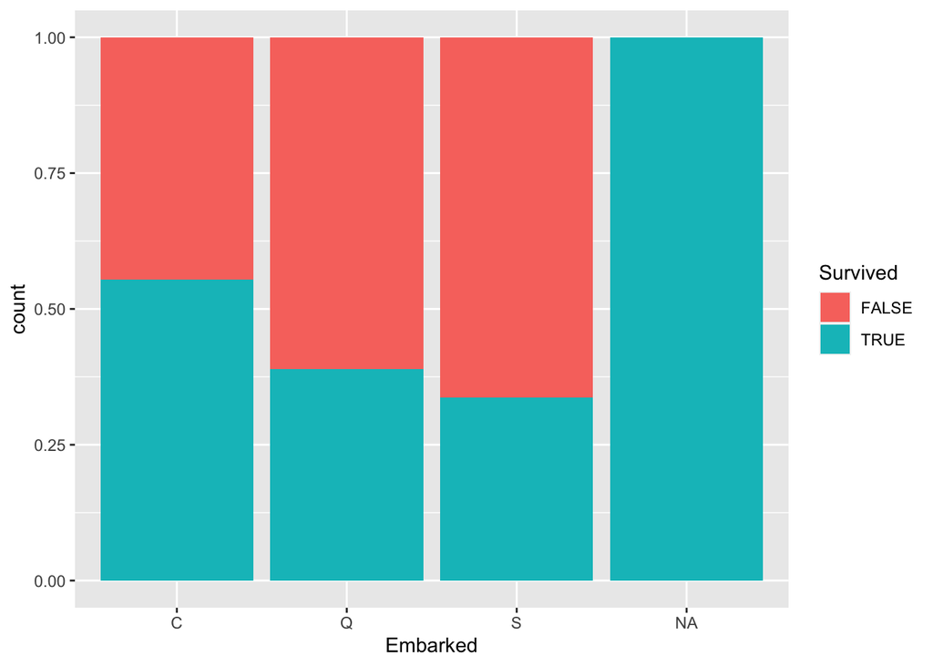

```r
ggplot(df_train, aes(Embarked, fill = Survived)) + geom_bar(position = "fill")
```

There are almost twice as many male passengers as female passengers.

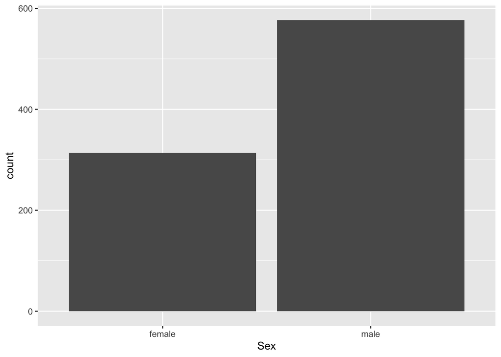

```r
ggplot(df_train, aes(Sex)) + geom_bar()
```

A much higher percentage of women than men survived.

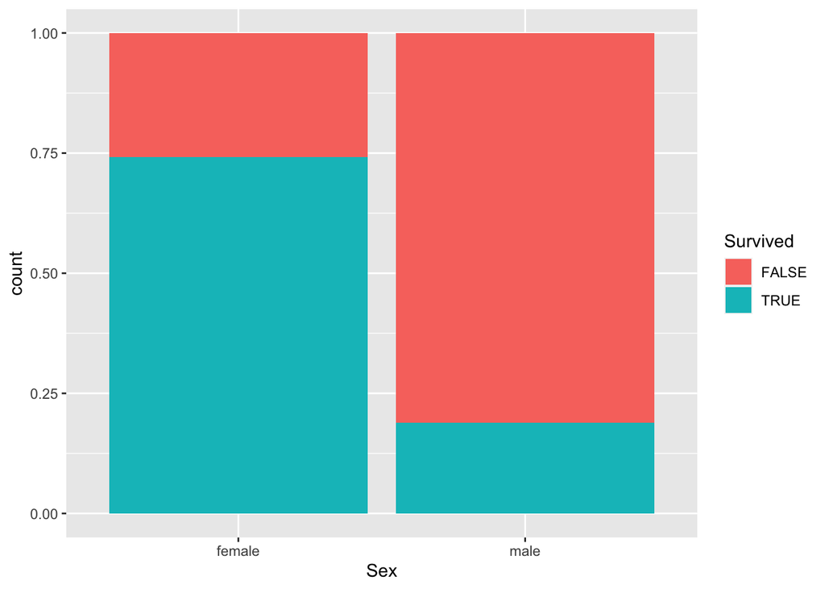

```r
ggplot(df_train, aes(Sex, fill = Survived)) + geom_bar(position = "fill")
```

Order of decreasing survival rate per `Embarked` factor level: `C > Q > S`.

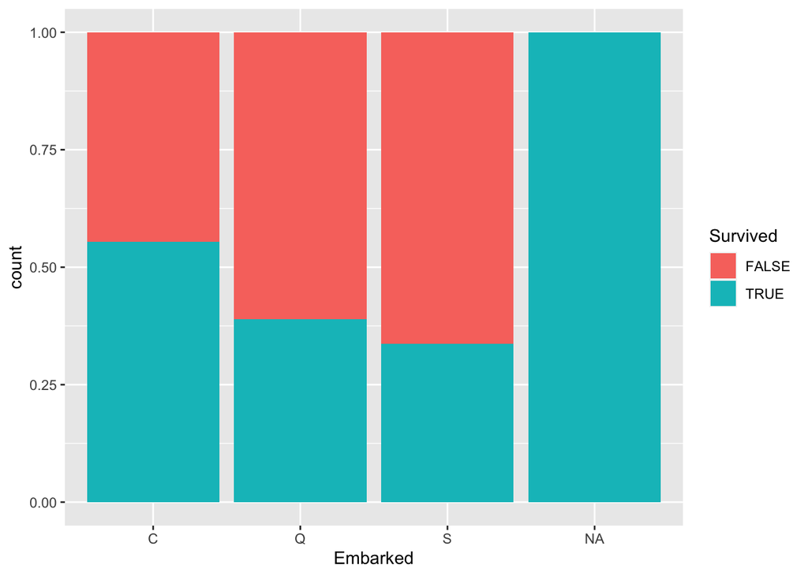

```r
ggplot(df_train, aes(Embarked, fill = Survived)) + geom_bar(position = "fill")
```

The higher the class number, the lower the chance of survival.

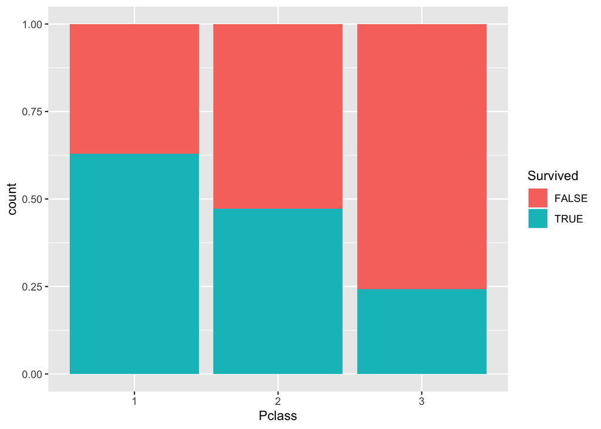

```r
ggplot(df_train, aes(Pclass, fill = Survived)) + geom_bar(position = "fill")
```

There’s a slightly lower chance of survival if `Age` is `NA`.

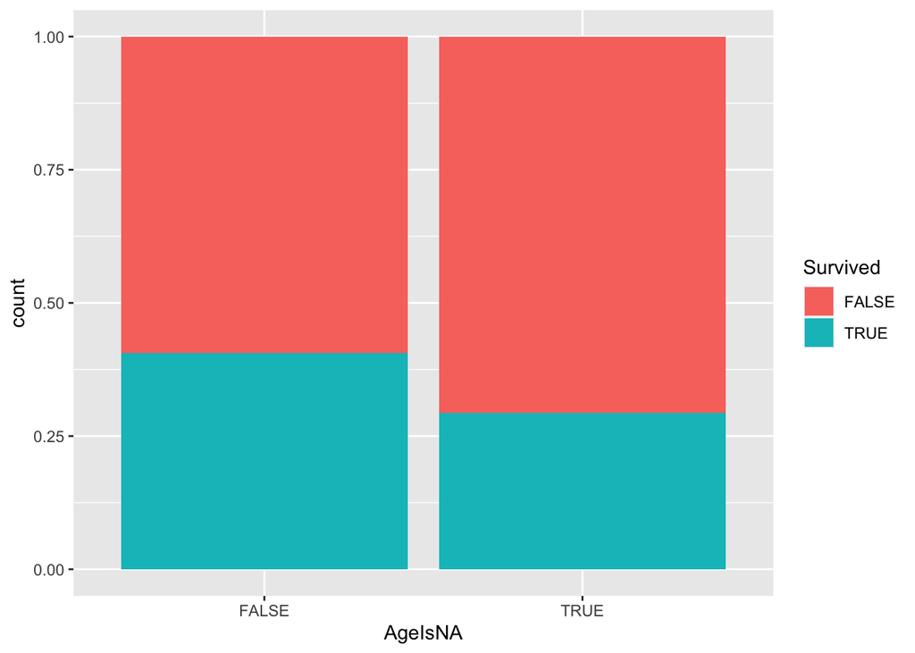

```r
ggplot(df_train, aes(AgeIsNA, fill = Survived)) + geom_bar(position = "fill")
```

There’s a much lower chance of survival if `Cabin` is `NA`.

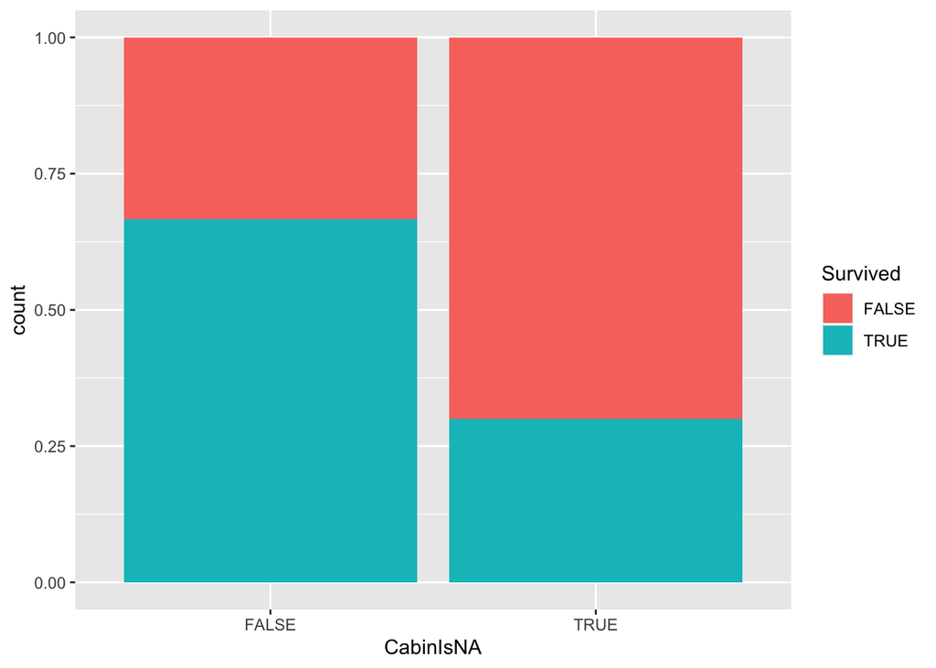

```r
ggplot(df_train, aes(CabinIsNA, fill = Survived)) + geom_bar(position = "fill")
```

It seems there isn’t much of a relationship between `Sex` and `Fare`.

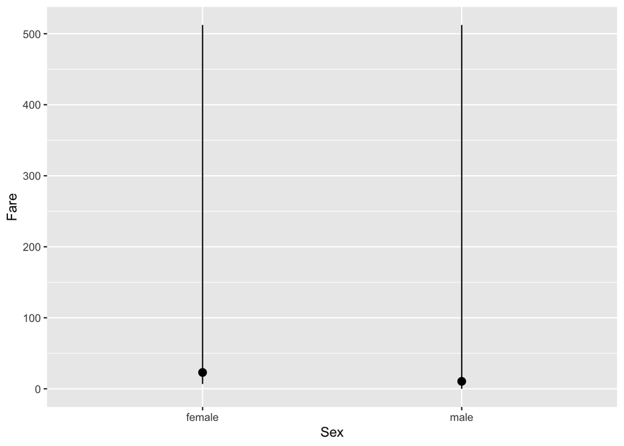

```r
ggplot(df_train) + stat_summary(aes(Sex, Fare), fun.min = min, fun.max = max, fun = median)
```

The median ages for men and women are about the same, but there are men much older than the oldest woman.

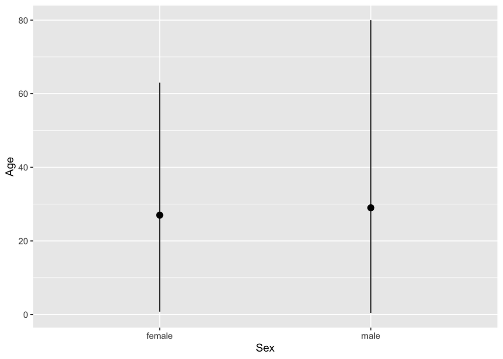

```r
ggplot(df_train) + stat_summary(aes(Sex, Age), fun.min = min, fun.max = max, fun = median)
```

No apparent relationship between one’s ticket being numeric and survival.

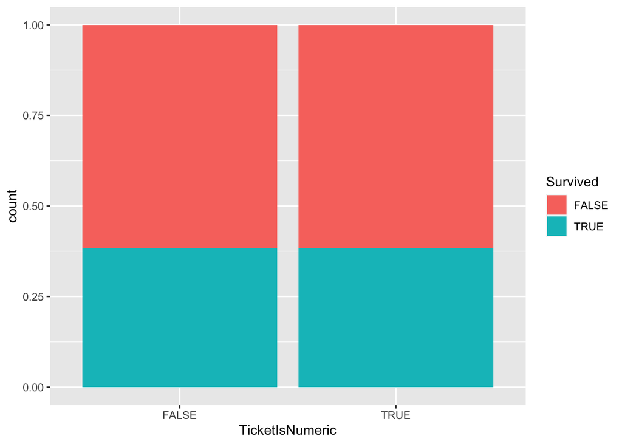

```r
ggplot(df_train, aes(TicketIsNumeric, fill = Survived)) + geom_bar(position = "fill")
```

There’s a slightly higher chance of survival if `SibSp == 1` or `SibSp == 2`. Beware of low counts in classes – we need to consider both counts and proportions.

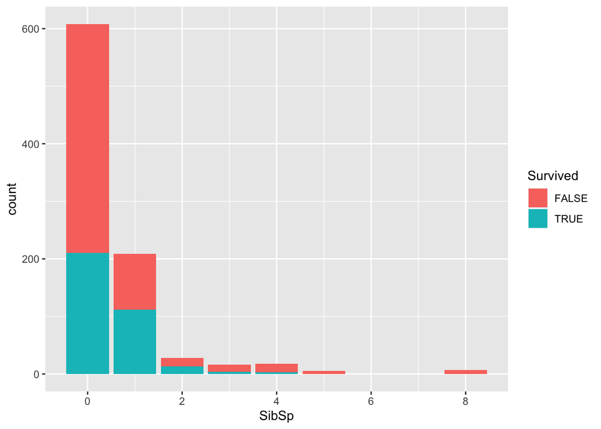

```r
## Counts
ggplot(df_train, aes(SibSp, fill = Survived)) + geom_bar()
```

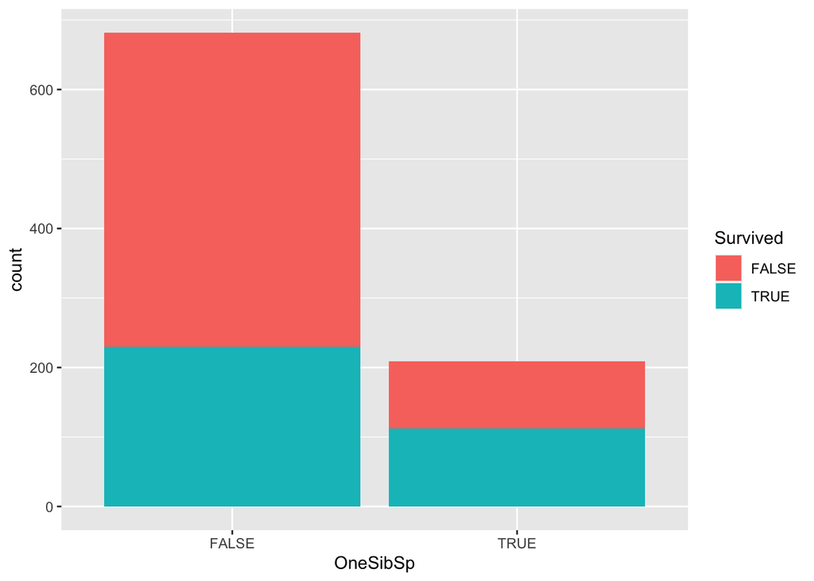

```r
ggplot(df_train, aes(OneSibSp, fill = Survived)) + geom_bar()
```

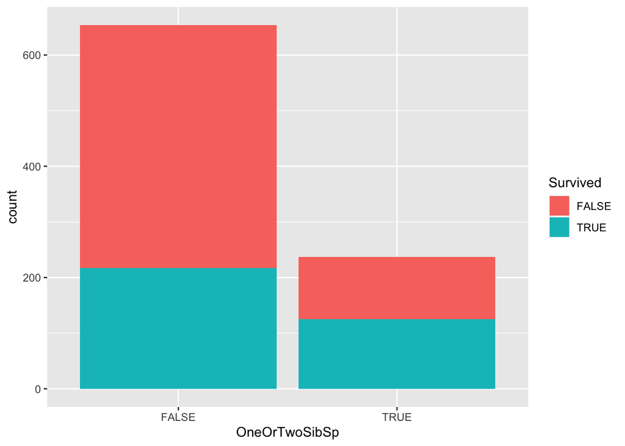

```r
ggplot(df_train, aes(OneOrTwoSibSp, fill = Survived)) + geom_bar()
```

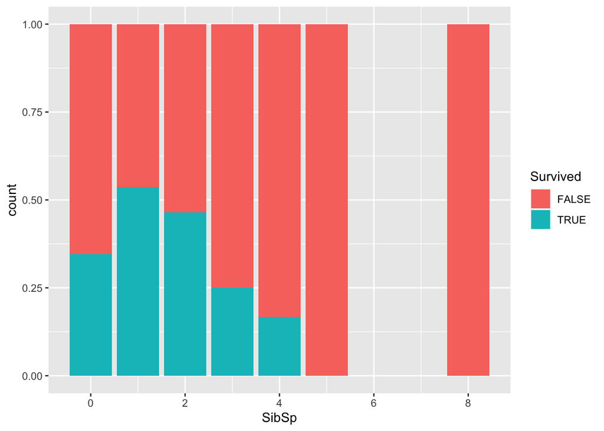

```r
## Proportions
ggplot(df_train, aes(SibSp, fill = Survived)) + geom_bar(position = "fill")
```

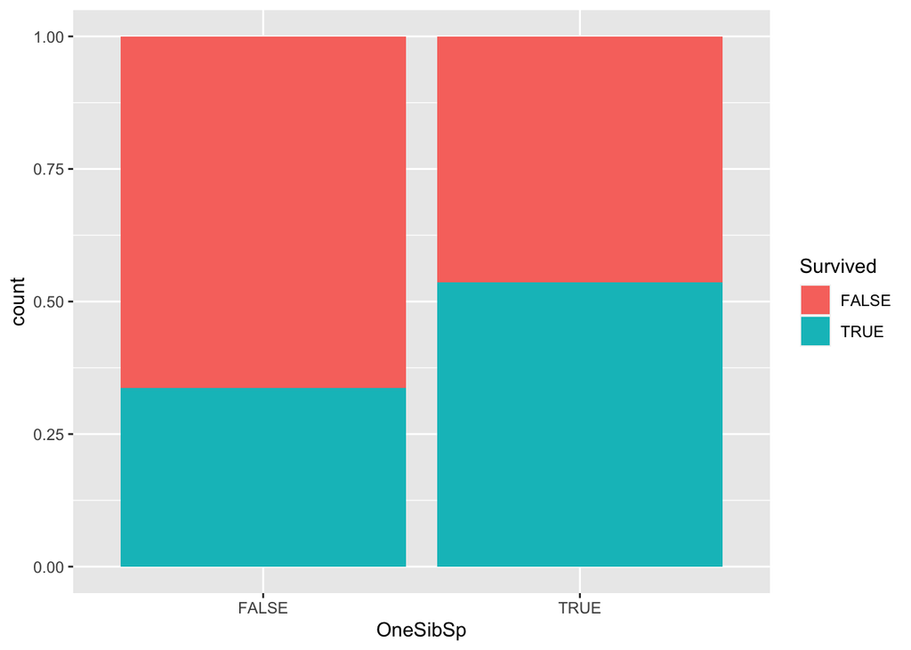

```r
ggplot(df_train, aes(OneSibSp, fill = Survived)) + geom_bar(position = "fill")
```

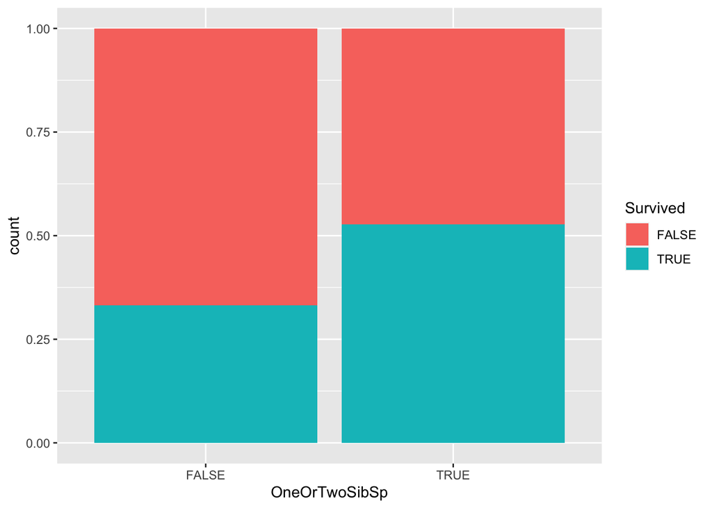

```r
ggplot(df_train, aes(OneOrTwoSibSp, fill = Survived)) + geom_bar(position = "fill")
```

Chance of survival is slightly greater if `Parch == 1`, `Parch == 2` or `Parch == 3`.

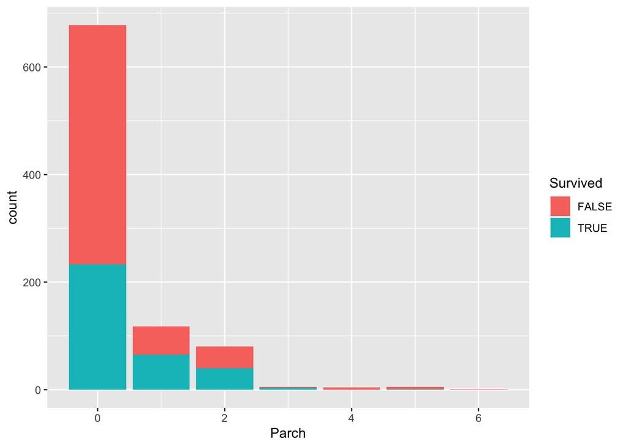

```r
## Counts
ggplot(df_train, aes(Parch, fill = Survived)) + geom_bar()
```

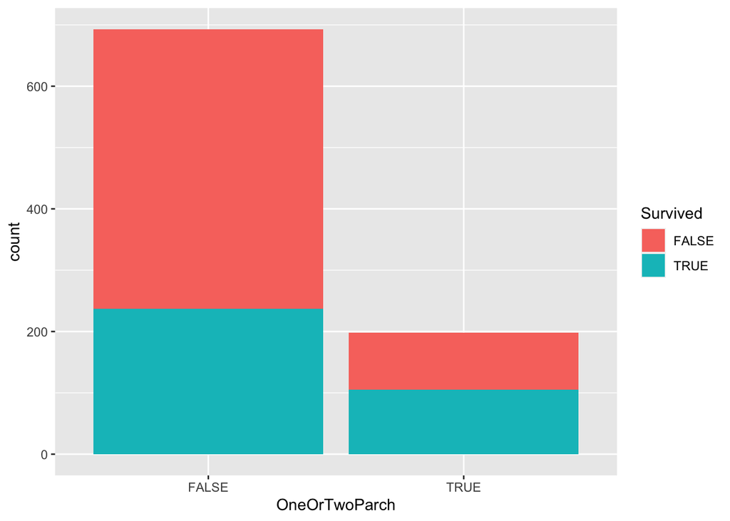

```r
ggplot(df_train, aes(OneOrTwoParch, fill = Survived)) + geom_bar()
```

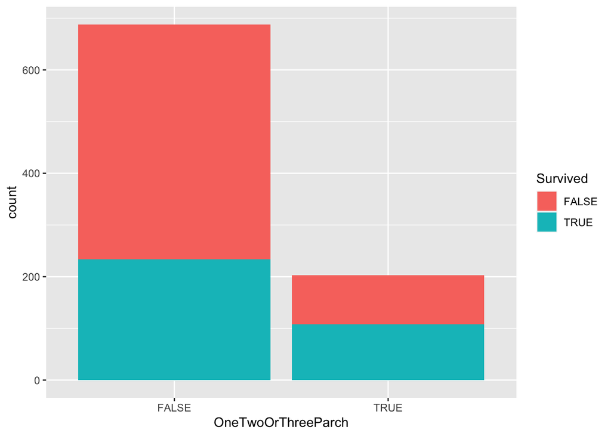

```r
ggplot(df_train, aes(OneTwoOrThreeParch, fill = Survived)) + geom_bar()
```

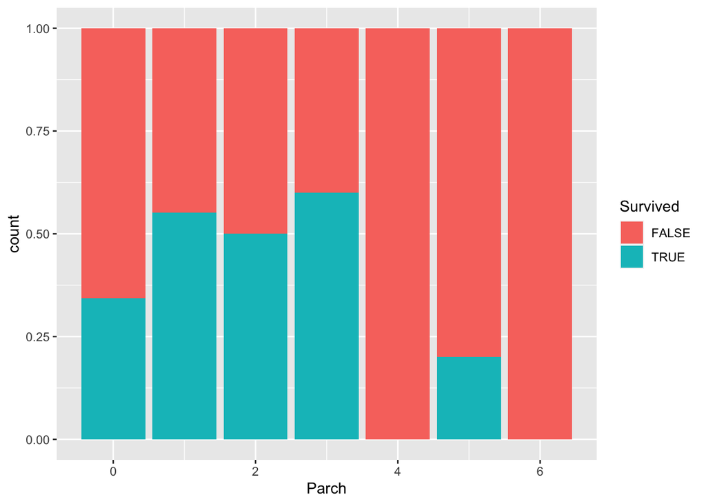

```r
## Proportions
ggplot(df_train, aes(Parch, fill = Survived)) + geom_bar(position = "fill")
```

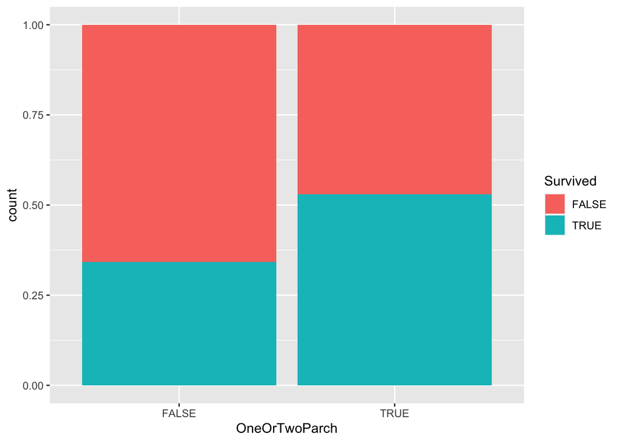

```r
ggplot(df_train, aes(OneOrTwoParch, fill = Survived)) + geom_bar(position = "fill")
```

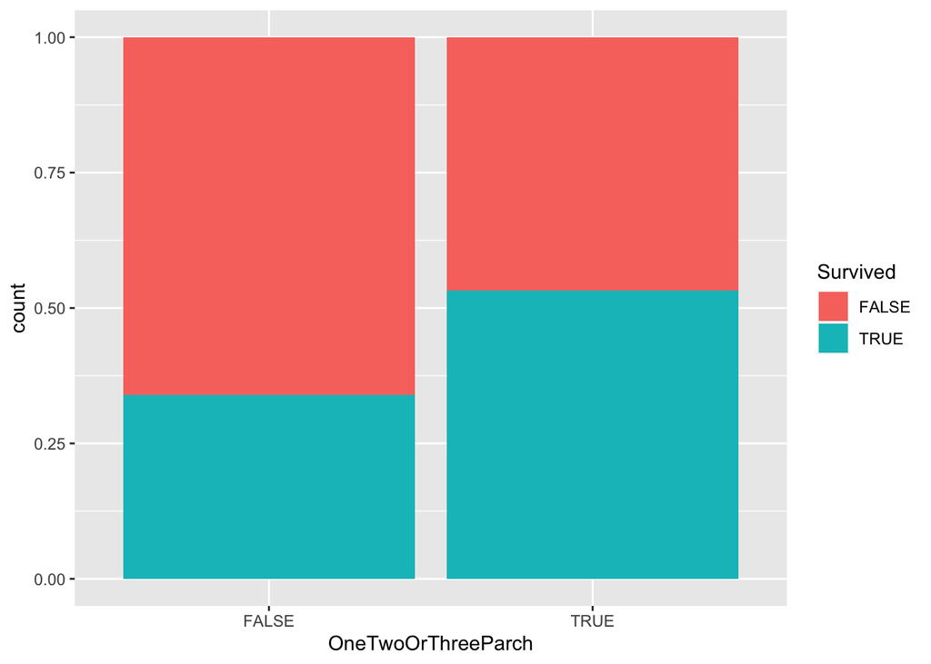

```r
ggplot(df_train, aes(OneTwoOrThreeParch, fill = Survived)) + geom_bar(position = "fill")
```

Much higher fares on average if `OneOrTwoParch == TRUE`.

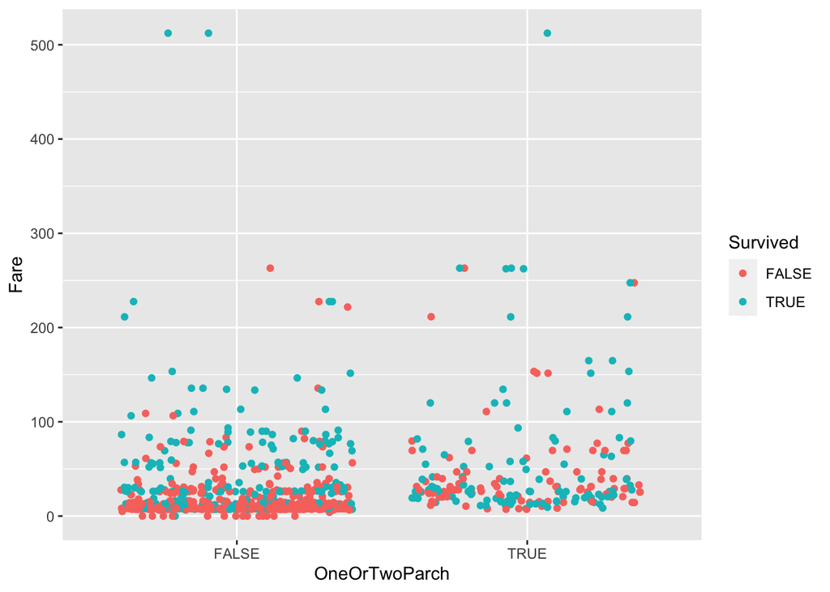

```r
ggplot(df_train, aes(OneOrTwoParch, Fare, color = Survived)) + geom_jitter()
```

```r
df_train %>% group_by(OneOrTwoParch) %>% summarize(MeanFare = mean(Fare)) %>% print()
```

```
## # A tibble: 2 x 2
##   OneOrTwoParch MeanFare
##   <lgl>            <dbl>
## 1 FALSE             26.0
## 2 TRUE              53.9
```

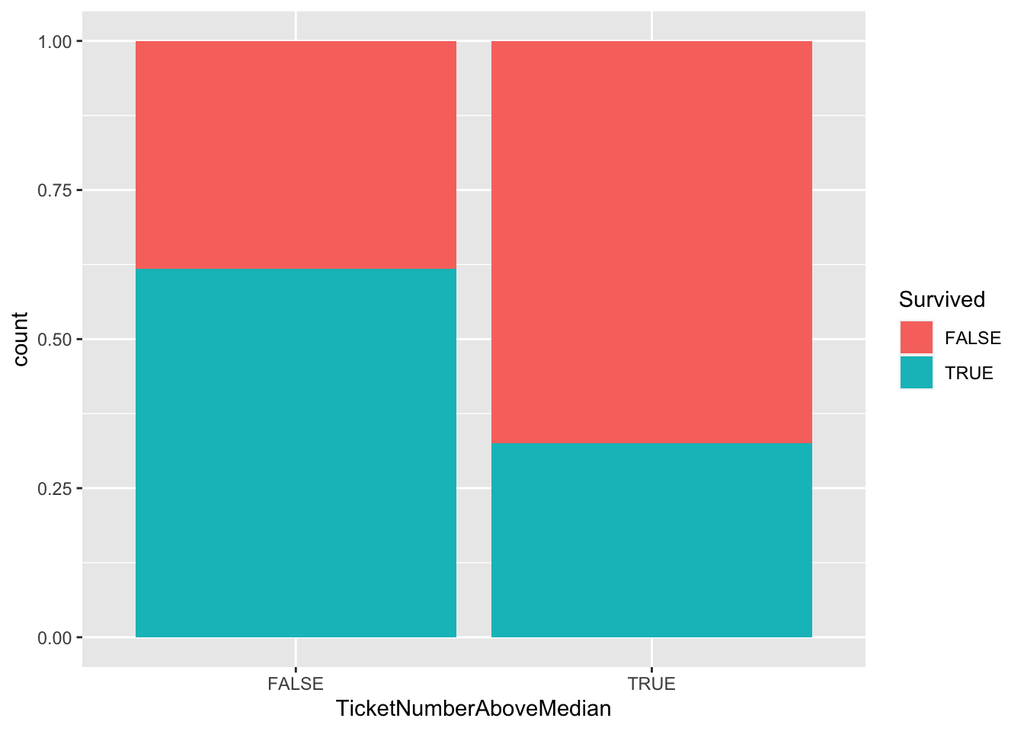

```r
ggplot(df_train, aes(TicketNumberAboveMedian, fill = Survived)) + geom_bar(position = "fill")
```

The young (age under 18) have a higher chance of survival.

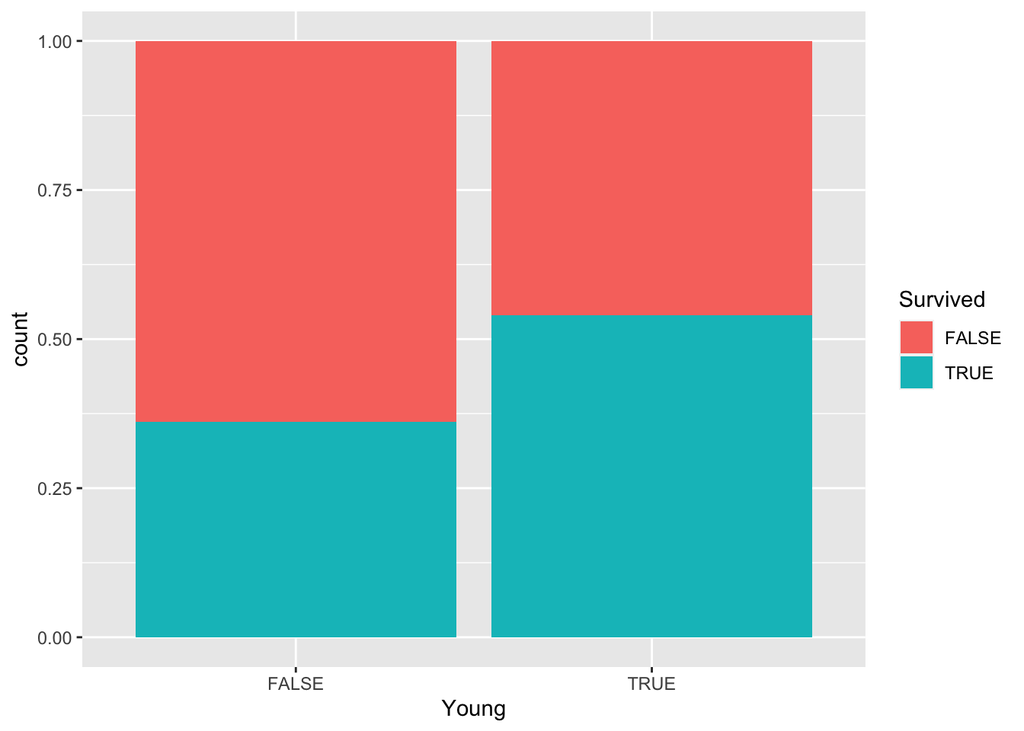

```r
ggplot(df_train, aes(Young, fill = Survived)) + geom_bar(position = "fill")
```

The relationship between `SibSp` and `Parch` shows that high values for either variable correspond to low survival.

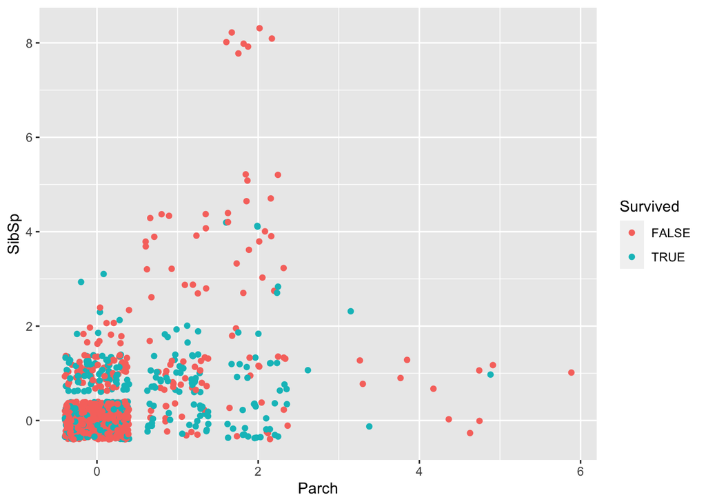

```r
ggplot(df_train, aes(Parch, SibSp)) + geom_jitter(aes(color = Survived))
```

Based on these visualizations, we will store variables that seem promising in `candidate_vars`. We will try all combinations of variables from `candidate_vars` in our models to find the best combination for each algorithm.

```r
candidate_vars <- c("Sex",
                    "Pclass",
                    "AgeIsNA",
                    "CabinIsNA",
                    "OneOrTwoSibSp",
                    "OneTwoOrThreeParch",
                    "TicketNumberAboveMedian",
                    "Young",
                    "ManyChildren",
                    "ManySiblings")
```

## Modeling

We’ll iterate through all possible combinations of variables in `candidate_vars` and train each of the following modeling algorithms: logistic regression, K nearest neighbors, random forests, gradient boosting machine, support vector machine, linear discriminant analysis, and naive Bayes.

First we split our training data for five-fold cross validation.

```r
# Generate folds for cross validation
df_train_splits <- list()
df_val_splits <- list()
num_folds <- 5

set.seed(1)
for (fold_index in seq(num_folds)) {
  sample_indices <- sample.split(df_train$PassengerId, SplitRatio = 1 / num_folds)
  df_train_split <- subset(df_train, sample_indices == FALSE)
  df_val_split <- subset(df_train, sample_indices == TRUE)
  df_train_splits[[fold_index]] <- df_train_split
  df_val_splits[[fold_index]] <- df_val_split
}
```

We’ll need to preprocess variables and add new features for the test set, just as we did for the training set earlier.

```r
df_test$Sex <- factor(df_test$Sex)
df_test$Pclass <- factor(df_test$Pclass)
df_test$AgeIsNA <- is.na(df_test$Age)
df_test$CabinIsNA <- is.na(df_test$Cabin)
df_test$OneOrTwoSibSp <- df_test$SibSp == 1 | df_test$SibSp == 2
df_test$OneTwoOrThreeParch <- df_test$Parch == 1 | df_test$Parch == 2 | df_test$Parch == 3
df_test$TicketNumberAboveMedian <- df_test$Ticket > median_ticket_number
df_test$Young <- df_test$Age < 18 & !is.na(df_test$Age)
df_test$ManyChildren <- df_test$Parch > 3
df_test$ManySiblings <- df_test$SibSp > 2
```

We define a helper function to convert formulas to a vector of variable names. We’ll be using this often.

```r
extractVariablesFromFormula <- function(formula) {
  return(unlist(strsplit(strsplit(as.character(list(formula)), " ~ ", fixed = TRUE)[[1]][2], " + ", fixed = TRUE)))
}
```

Now we begin training. For each algorithm, we’ll iterate through all combinations of `candidate_vars`, and occasionally we’ll iterate through some algorithm-specific hyperparameters as well. We’ll extract the best model, along with its formula, prediction rate (which we’ll print), and any hyperparameter values. We’ll compute predictions for the test set using each algorithm’s best model along the way. Note that we could’ve combined all the algorithms into one big loop, but the hyperparameters and syntax for the various algorithms are different enough to make such a loop very unwieldy. It’s much clearer to split them up like this.

Note that training may take a few minutes for each algorithm.

### Logistic regression (generalized linear model)

```r
formula_list <- list()
prediction_rate_list <- list()
mean_threshold_list <- list()
formula_index <- 1

for (num_vars in seq(length(candidate_vars))) {
  vars_combos <- combn(candidate_vars, num_vars)
  for (combo_idx in seq(ncol(vars_combos))) {
    formula <- as.formula(paste("Survived", paste(vars_combos[,combo_idx], collapse = " + "), sep = "~"))
    prediction_rate <- list()
    threshold_list <- list()
    for (fold_index in seq(num_folds)) {
      df_train_split <- df_train_splits[[fold_index]]
      df_val_split <- df_val_splits[[fold_index]]
      model_binomial <- glm(formula, df_train_split, family = "binomial")
      probabilities <- predict(model_binomial, df_val_split, type = "response")
      roc_obj <- roc(df_val_split$Survived, probabilities, quiet = TRUE)
      threshold <- coords(roc_obj, "best", "threshold", transpose = FALSE)$threshold
      if (all(is.finite(threshold))) {
        threshold_list[[fold_index]] <- threshold
        predictions <- probabilities > threshold
        prediction_rate[[fold_index]] <- mean(predictions == df_val_split$Survived)
      } else {
        threshold_list[[fold_index]] <- NA
        prediction_rate[[fold_index]] <- NA
      }
    }
    formula_list[[formula_index]] <- formula
    prediction_rate_list[[formula_index]] <- mean(as.numeric(prediction_rate), na.rm = TRUE)
    mean_threshold_list[[formula_index]] <- mean(as.numeric(threshold_list), na.rm = TRUE)
    formula_index <- formula_index + 1
  }
}

# Train on full training set and compute predictions for test set
best_glm_formula <- formula_list[[which.max(unlist(prediction_rate_list))]]
best_glm_prediction_rate <- max(unlist(prediction_rate_list))
glm_threshold <- mean_threshold_list[[which.max(unlist(prediction_rate_list))]]
print(str_c("Best Generalized Linear Model prediction rate: ", best_glm_prediction_rate))
```

```
## [1] "Best Generalized Linear Model prediction rate: 0.797752808988764"
```

```r
best_model_glm <- glm(best_glm_formula, df_train, family = "binomial")
glm_probabilities <- predict(best_model_glm, df_test, type = "response")
glm_predictions <- as.numeric(glm_probabilities > glm_threshold)
```

### K nearest neighbors

```r
best_formula_list <- list()
best_prediction_rate_list <- list()
k_candidates <- c(1, 3, 5, 10, 20, 50)

for (k in k_candidates) {
  formula_list <- list()
  prediction_rate_list <- list()
  formula_index <- 1
  for (num_vars in seq(length(candidate_vars))) {
    vars_combos <- combn(candidate_vars, num_vars)
    for (combo_idx in seq(ncol(vars_combos))) {
      formula <- as.formula(paste("Survived", paste(vars_combos[,combo_idx], collapse = " + "), sep = "~"))
      prediction_rate <- list()
      for (fold_index in seq(num_folds)) {
        df_train_split <- dplyr::select(df_train_splits[[fold_index]], vars_combos[,combo_idx]) %>% sapply(as.numeric) %>% scale() %>% as.data.frame()
        df_val_split <- dplyr::select(df_val_splits[[fold_index]], vars_combos[,combo_idx]) %>% sapply(as.numeric) %>% scale() %>% as.data.frame()
        predictions <- knn(df_train_split, df_val_split, df_train_splits[[fold_index]]$Survived, k = k)
        prediction_rate[[fold_index]] <- mean(predictions == df_val_splits[[fold_index]]$Survived)
      }
      formula_list[[formula_index]] <- formula
      prediction_rate_list[[formula_index]] <- mean(as.numeric(prediction_rate))
      formula_index <- formula_index + 1
    }
  }
  best_formula_list <- append(best_formula_list, formula_list[which.max(unlist(prediction_rate_list))])
  best_prediction_rate_list <- append(best_prediction_rate_list, max(unlist(prediction_rate_list)))
}

# Train on full training set and compute predictions for test set
# Choose the best k value for KNN
best_k <- k_candidates[[which.max(best_prediction_rate_list)]]
best_knn_formula <- best_formula_list[[which.max(unlist(best_prediction_rate_list))]]
best_knn_vars <- extractVariablesFromFormula(best_knn_formula)
best_knn_prediction_rate <- max(unlist(best_prediction_rate_list))
print(str_c("Best K Nearest Neighbors prediction rate: ", best_knn_prediction_rate))
```

```
## [1] "Best K Nearest Neighbors prediction rate: 0.81123595505618"
```

```r
df_train_knn <- dplyr::select(df_train, all_of(best_knn_vars)) %>% sapply(as.numeric) %>% scale() %>% as.data.frame()
df_test_knn <- dplyr::select(df_test, all_of(best_knn_vars)) %>% sapply(as.numeric) %>% scale() %>% as.data.frame()
knn_predictions <- as.numeric(as.logical(knn(df_train_knn, df_test_knn, df_train$Survived, k = best_k)))
```

### Random forest without class weights

```r
formula_list <- list()
prediction_rate_list <- list()
formula_index <- 1

for (num_vars in seq(length(candidate_vars))) {
  vars_combos <- combn(candidate_vars, num_vars)
  for (combo_idx in seq(ncol(vars_combos))) {
    prediction_rate <- list()
    for (fold_index in seq(num_folds)) {
      df_train_split <- df_train_splits[[fold_index]]
      df_train_split$Survived <- factor(df_train_split$Survived)  # without this line, randomForest() will perform regression instead of classification
      df_val_split <- df_val_splits[[fold_index]]
      formula <- as.formula(paste("Survived", paste(vars_combos[,combo_idx], collapse = " + "), sep = "~"))
      model_random_forest <- randomForest(formula, data = df_train_split, importance = TRUE)
      predictions <- predict(model_random_forest, df_val_split, type = "class")
      prediction_rate[[fold_index]] <- mean(predictions == df_val_split$Survived)
    }
    formula_list[[formula_index]] <- formula
    prediction_rate_list[[formula_index]] <- mean(as.numeric(prediction_rate))
    formula_index <- formula_index + 1
  }
}

# Train on full training set and compute predictions for test set
best_rf_formula <- formula_list[[which.max(unlist(prediction_rate_list))]]
best_rf_prediction_rate <- max(unlist(prediction_rate_list))
print(str_c("Best Random Forest prediction rate: ", best_rf_prediction_rate))
```

```
## [1] "Best Random Forest prediction rate: 0.802247191011236"
```

```r
df_train_rf <- df_train
df_train_rf$Survived <- factor(df_train_rf$Survived)  # without this line, randomForest() will perform regression instead of classification
best_model_rf <- randomForest(best_rf_formula, df_train_rf)
rf_predictions <- as.numeric(as.logical(predict(best_model_rf, df_test)))
```

### Random forest with class weights

```r
# Compute class weights for more balanced training
passenger_count <- count(df_train)$n
survivor_count <- df_train$Survived %>% as.numeric() %>% sum()
class_weights <- c(passenger_count / (2 * (passenger_count - survivor_count)), passenger_count / (2 * survivor_count))

formula_list <- list()
prediction_rate_list <- list()
formula_index <- 1

for (num_vars in seq(length(candidate_vars))) {
  vars_combos <- combn(candidate_vars, num_vars)
  for (combo_idx in seq(ncol(vars_combos))) {
    prediction_rate <- list()
    for (fold_index in seq(num_folds)) {
      df_train_split <- df_train_splits[[fold_index]]
      df_train_split$Survived <- factor(df_train_split$Survived)  # without this line, randomForest() will perform regression instead of classification
      df_val_split <- df_val_splits[[fold_index]]
      formula <- as.formula(paste("Survived", paste(vars_combos[,combo_idx], collapse = " + "), sep = "~"))
      model_random_forest <- randomForest(formula, data = df_train_split, importance = TRUE, classwt = class_weights)
      predictions <- predict(model_random_forest, df_val_split, type = "class")
      prediction_rate[[fold_index]] <- mean(predictions == df_val_split$Survived)
    }
    formula_list[[formula_index]] <- formula
    prediction_rate_list[[formula_index]] <- mean(as.numeric(prediction_rate))
    formula_index <- formula_index + 1
  }
}

# Train on full training set and compute predictions for test set
best_weighted_rf_formula <- formula_list[[which.max(unlist(prediction_rate_list))]]
best_weighted_rf_prediction_rate <- max(unlist(prediction_rate_list))
print(str_c("Best Weighted Random Forest prediction rate: ", best_weighted_rf_prediction_rate))
```

```
## [1] "Best Weighted Random Forest prediction rate: 0.803370786516854"
```

```r
best_model_weighted_rf <- randomForest(best_weighted_rf_formula, df_train_rf)
weighted_rf_predictions <- as.numeric(as.logical(predict(best_model_weighted_rf, df_test)))
```

### Gradient boosting machine

```r
# Need to convert logicals to factors for gbm()
logical_variables <- df_train %>% dplyr::select(all_of(candidate_vars)) %>% sapply(is.logical)
logical_variables <- names(logical_variables[logical_variables])

formula_list <- list()
prediction_rate_list <- list()
mean_threshold_list <- list()
formula_index <- 1

for (num_vars in seq(length(candidate_vars))) {
  vars_combos <- combn(candidate_vars, num_vars)
  for (combo_idx in seq(ncol(vars_combos))) {
    prediction_rate <- list()
    threshold_list <- list()
    for (fold_index in seq(num_folds)) {
      df_train_split <- df_train_splits[[fold_index]]
      df_val_split <- df_val_splits[[fold_index]]
      for (var in logical_variables) {
        df_train_split[[var]] <- factor(df_train_split[[var]])
        df_val_split[[var]] <- factor(df_val_split[[var]])
      }
      formula <- as.formula(paste("Survived", paste(vars_combos[,combo_idx], collapse = " + "), sep = "~"))
      model_gbm <- gbm(formula, data = df_train_split, distribution = "bernoulli", n.trees = 100, interaction.depth = 3, shrinkage = 0.1)
      probabilities <- predict(model_gbm, df_val_split, n.trees = seq(100), type = "response") %>% rowMeans()
      roc_obj <- roc(df_val_split$Survived, probabilities, quiet = TRUE)
      threshold <- coords(roc_obj, "best", "threshold", transpose = FALSE)$threshold
      if (all(is.finite(threshold))) {
        threshold_list[[fold_index]] <- threshold
        predictions <- probabilities > threshold
        prediction_rate[[fold_index]] <- mean(predictions == df_val_split$Survived)
      } else {
        threshold_list[[fold_index]] <- NA
        prediction_rate[[fold_index]] <- NA
      }
    }
    formula_list[[formula_index]] <- formula
    prediction_rate_list[[formula_index]] <- mean(as.numeric(prediction_rate), na.rm = TRUE)
    mean_threshold_list[[formula_index]] <- mean(as.numeric(threshold_list), na.rm = TRUE)
    formula_index <- formula_index + 1
  }
}

# Train on full training set and compute predictions for test set
df_train_gbm <- df_train
df_test_gbm <- df_test
for (var in logical_variables) {
  df_train_gbm[[var]] <- factor(df_train_gbm[[var]])
  df_test_gbm[[var]] <- factor(df_test_gbm[[var]])
}
best_gbm_formula <- formula_list[[which.max(unlist(prediction_rate_list))]]
best_gbm_prediction_rate <- max(unlist(prediction_rate_list), na.rm = TRUE)
gbm_threshold <- mean_threshold_list[[which.max(unlist(prediction_rate_list))]]
print(str_c("Best Gradient Boosting Machine prediction rate: ", best_gbm_prediction_rate))
```

```
## [1] "Best Gradient Boosting Machine prediction rate: 0.80561797752809"
```

```r
best_model_gbm <- gbm(best_gbm_formula, data = df_train_gbm, distribution = "bernoulli", n.trees = 100, interaction.depth = 3, shrinkage = 0.1)
gbm_probabilities <- predict(best_model_gbm, df_test_gbm, n.trees = seq(100), type = "response") %>% rowMeans()
gbm_predictions <- as.numeric(gbm_probabilities > gbm_threshold)
```

### Support vector machine with polynomial kernel

```r
# Remove Age, Cabin, Embarked, Fare from data because they contain NAs, and svm() omits predictions for rows with NAs
vars_to_remove <- union(vars_with_NAs_test, vars_with_NAs_train)

# Compute class weights for more balanced training
passenger_count <- count(df_train)$n
survivor_count <- df_train$Survived %>% as.numeric() %>% sum()
class_weights <- c(passenger_count / (2 * (passenger_count - survivor_count)), passenger_count / (2 * survivor_count))
names(class_weights) <- c("FALSE", "TRUE")

formula_list <- list()
prediction_rate_list <- list()
formula_index <- 1

for (num_vars in seq(length(candidate_vars))) {
  vars_combos <- combn(candidate_vars, num_vars)
  for (combo_idx in seq(ncol(vars_combos))) {
    formula <- as.formula(paste("Survived", paste(vars_combos[,combo_idx], collapse = " + "), sep = "~"))
    prediction_rate <- list()
    for (fold_index in seq(num_folds)) {
      # remove variables with NAs
      df_train_split <- df_train_splits[[fold_index]] %>% dplyr::select(-one_of(vars_to_remove))
      df_val_split <- df_val_splits[[fold_index]] %>% dplyr::select(-one_of(vars_to_remove))
      model_svm <- svm(formula, df_train_split, type = "C-classification", kernel = "polynomial", cost = 100, scale = FALSE, class.weights = class_weights)
      predictions <- predict(model_svm, df_val_split)
      prediction_rate[[fold_index]] <- mean(predictions == df_val_split$Survived)
    }
    formula_list[[formula_index]] <- formula
    prediction_rate_list[[formula_index]] <- mean(as.numeric(prediction_rate), na.rm = TRUE)
    formula_index <- formula_index + 1
  }
}

# Train on full training set and compute predictions for test set
best_svm_formula <- formula_list[[which.max(unlist(prediction_rate_list))]]
best_svm_prediction_rate <- max(unlist(prediction_rate_list), na.rm = TRUE)
print(str_c("Best Support Vector Machine prediction rate: ", best_svm_prediction_rate))
```

```
## [1] "Best Support Vector Machine prediction rate: 0.806741573033708"
```

```r
df_train_svm <- df_train %>% dplyr::select(-one_of(vars_to_remove))
df_test_svm <- df_test %>% dplyr::select(-one_of(vars_to_remove))
best_model_svm <- svm(best_svm_formula, df_train_svm, type = "C-classification", kernel = "polynomial", cost = 100, scale = FALSE, class.weights = class_weights)
svm_predictions <- as.numeric(as.logical(predict(best_model_svm, df_test_svm)))
```

### Linear discriminant analysis

```r
formula_list <- list()
prediction_rate_list <- list()
formula_index <- 1

for (num_vars in seq(length(candidate_vars))) {
  vars_combos <- combn(candidate_vars, num_vars)
  for (combo_idx in seq(ncol(vars_combos))) {
    formula <- as.formula(paste("Survived", paste(vars_combos[,combo_idx], collapse = " + "), sep = "~"))
    prediction_rate <- list()
    for (fold_index in seq(num_folds)) {
      df_train_split <- df_train_splits[[fold_index]]
      df_val_split <- df_val_splits[[fold_index]]
      model_lda <- lda(formula, df_train_split)
      predictions <- predict(model_lda, df_val_split)$class
      prediction_rate[[fold_index]] <- mean(predictions == df_val_split$Survived)
    }
    formula_list[[formula_index]] <- formula
    prediction_rate_list[[formula_index]] <- mean(as.numeric(prediction_rate), na.rm = TRUE)
    formula_index <- formula_index + 1
  }
}

# Train on full training set and compute predictions for test set
best_lda_formula <- formula_list[[which.max(unlist(prediction_rate_list))]]
best_lda_prediction_rate <- max(unlist(prediction_rate_list), na.rm = TRUE)
print(str_c("Best Linear Discriminant Analysis prediction rate: ", best_lda_prediction_rate))
```

```
## [1] "Best Linear Discriminant Analysis prediction rate: 0.785393258426966"
```

```r
best_model_lda <- lda(best_lda_formula, df_train)
lda_predictions <- as.numeric(as.logical(predict(best_model_lda, df_test)$class))
```

### Naive Bayes

```r
formula_list <- list()
prediction_rate_list <- list()
formula_index <- 1

for (num_vars in seq(length(candidate_vars))) {
  vars_combos <- combn(candidate_vars, num_vars)
  for (combo_idx in seq(ncol(vars_combos))) {
    formula <- as.formula(paste("Survived", paste(vars_combos[,combo_idx], collapse = " + "), sep = "~"))
    prediction_rate <- list()
    for (fold_index in seq(num_folds)) {
      df_train_split <- df_train_splits[[fold_index]]
      df_val_split <- df_val_splits[[fold_index]]
      model_nb <- naiveBayes(formula, df_train_split)
      suppressWarnings(predictions <- predict(model_nb, df_val_split))  # there are some NA coercion warnings here
      prediction_rate[[fold_index]] <- mean(predictions == df_val_split$Survived)
    }
    formula_list[[formula_index]] <- formula
    prediction_rate_list[[formula_index]] <- mean(as.numeric(prediction_rate), na.rm = TRUE)
    formula_index <- formula_index + 1
  }
}

# Train on full training set and compute predictions for test set
best_nb_formula <- formula_list[[which.max(unlist(prediction_rate_list))]]
best_nb_prediction_rate <- max(unlist(prediction_rate_list), na.rm = TRUE)
print(str_c("Best Naive Bayes prediction rate: ", best_nb_prediction_rate))
```

```
## [1] "Best Naive Bayes prediction rate: 0.78876404494382"
```

```r
best_model_nb <- naiveBayes(best_nb_formula, df_train)
suppressWarnings(nb_predictions <- as.numeric(predict(best_model_nb, df_test)))
```

Here we print a summary of our best models for each algorithm together for convenience.

```r
print(str_c("Best Generalized Linear Model prediction rate: ", best_glm_prediction_rate))
print(str_c("Best K Nearest Neighbors prediction rate: ", best_knn_prediction_rate))
print(str_c("Best Random Forest prediction rate: ", best_rf_prediction_rate))
print(str_c("Best Weighted Random Forest prediction rate: ", best_weighted_rf_prediction_rate))
print(str_c("Best Gradient Boosting Machine prediction rate: ", best_gbm_prediction_rate))
print(str_c("Best Support Vector Machine prediction rate: ", best_svm_prediction_rate))
print(str_c("Best Linear Discriminant Analysis prediction rate: ", best_lda_prediction_rate))
print(str_c("Best Naive Bayes prediction rate: ", best_nb_prediction_rate))
```

```
## [1] "Best Generalized Linear Model prediction rate: 0.797752808988764"
## [1] "Best K Nearest Neighbors prediction rate: 0.81123595505618"
## [1] "Best Random Forest prediction rate: 0.802247191011236"
## [1] "Best Weighted Random Forest prediction rate: 0.803370786516854"
## [1] "Best Gradient Boosting Machine prediction rate: 0.80561797752809"
## [1] "Best Support Vector Machine prediction rate: 0.806741573033708"
## [1] "Best Linear Discriminant Analysis prediction rate: 0.785393258426966"
## [1] "Best Naive Bayes prediction rate: 0.78876404494382"
```

## Submission file generation

We stack our best models for each algorithm by simply taking the mode of their predictions.

```r
# Submission 1: Mode of all models' predictions
final_predictions <- cbind(glm_predictions, knn_predictions, rf_predictions, weighted_rf_predictions, gbm_predictions, svm_predictions, lda_predictions, nb_predictions) %>% rowMeans() %>% round()
submission1 <- tibble("PassengerId" = df_test$PassengerId, "Survived" = final_predictions)
write_csv(submission1, "submission1.csv")

# Submission 2: Mode of best 3 models
final_predictions <- cbind(knn_predictions, gbm_predictions, svm_predictions) %>% rowMeans() %>% round()
submission2 <- tibble("PassengerId" = df_test$PassengerId, "Survived" = final_predictions)
write_csv(submission2, "submission2.csv")
```

Submitting these generated csv files to [Kaggle](https://www.kaggle.com/c/titanic) will produce public leaderboard scores of `0.78468` and `0.78947` respectively, the latter of which places us in the top 22%.

## Final thoughts

We’ve achieved a decent score, but there’s clearly room for improvement. At this point it would be a good idea to perform exploratory data analysis again now that we’ve seen which variables our modeling algorithms found useful. We’re better informed now. This may lead to ideas for new features, and we may also want to consider other modeling algorithms. It may also be a good idea to consider some of the variables we’ve ignored, like `Name`,`Embarked`, or numbers and letters in `Cabin`. There may exist patterns we haven’t yet explored. We can perform several rounds of data exploration and modeling to improve our score. However, we should take care not to overfit the validation data (and hence the training data). Increasing the validation split from 20% to a higher percentage, applying stronger regularization to our models, or choosing modeling algorithms that are structured to exhibit higher bias and lower variance may help us fight overfitting.